[output not shown]

```r
library("gplots")
library("multcomp")
```

# Analyse des données Par Territoire de santé (ex.secteur sanitaires)

## Variables globales:

```r
source("../prologue.R")
```

```
## [1] "Fichier courant: rpu2013d0112.Rda"
```

```r
library("gplots")
library("multcomp")
```

## Populations par territoire de santé

Quel est le nombre d’habitants des 4 territoires de santé et des 12 territoires de proximité ?

Pour faire le calcul, il faut merger:

- **zp.csv** /home/bart-rescue/Documents/JCB/R/RPU2013/cartograhie/data/zp.csv
- **newPopAlsace.Rda** /home/bart-rescue/Documents/JCB/R/RPU2013/Demographie/newPopAlsace.Rda. *newPop.Alsace* liste la population par tranches d’age de 1 an et par sexe. Il faut faire le total par commune via la fonction *tapply* (il faut coerciser en factor la rubrique CODGEO pour éliminer tous les codes INSEE qui ne correspondent pqs à l’Alsace. Défaut de newPopAlsace à corriger dans le fichier source). On obtient **pop_commune**, population par commune. Il faut l’associer au code INSEE, ce qui donne le dataframe **pop2010**.

On peut merger **zp** et **pop2010** pour former la population par territoire **pop.tt**.

A partir de *pop.tt* on extrait via tapply les population des territoires de santé **pop.ts** et des zones de proximités **pop.zp**.

```r
zp <- read.csv("~/Documents/Resural/Stat Resural/RPU_2013/doc/cartographie/data/zp.csv")
names(zp)
```

```
## [1] "CODE.DEP"                         "CODE.COMMUNE"
## [3] "LIBELLE.DES.COMMUNES"             "LIBELLE.DES.TERRITOIRES.DE.SANTE"
## [5] "CODE.ZONES.DE.PROXIMITE"          "LIBELLE.DES.ZONES.DE.PROXIMITE"
```

```r
head(zp)
```

```
##   CODE.DEP CODE.COMMUNE LIBELLE.DES.COMMUNES
## 1       68        68002             Altenach
## 2       68        68004             Altkirch
## 3       68        68006         Ammerzwiller
## 4       68        68010               Aspach
## 5       68        68017          Ballersdorf
## 6       68        68018         Balschwiller
##   LIBELLE.DES.TERRITOIRES.DE.SANTE CODE.ZONES.DE.PROXIMITE
## 1            TERRITOIRE DE SANTE 4                      11
## 2            TERRITOIRE DE SANTE 4                      11
## 3            TERRITOIRE DE SANTE 4                      11
## 4            TERRITOIRE DE SANTE 4                      11
## 5            TERRITOIRE DE SANTE 4                      11
## 6            TERRITOIRE DE SANTE 4                      11
##   LIBELLE.DES.ZONES.DE.PROXIMITE
## 1                       ALTKIRCH
## 2                       ALTKIRCH
## 3                       ALTKIRCH
## 4                       ALTKIRCH
## 5                       ALTKIRCH
## 6                       ALTKIRCH
```

```r
load("~/Documents/Resural/Stat Resural/RPU_2013/doc/Demographie/newPopAlsace.Rda")
names(newPopAlsace)
```

```
## [1] "NIVEAU"   "CODGEO"   "REG"      "DEP"      "C_AGED10" "C_SEXE"
## [7] "NB"
```

```r
head(newPopAlsace)
```

```
##         NIVEAU CODGEO REG DEP C_AGED10 C_SEXE     NB
## 3857428    COM  67001  42  67        0      1  4.245
## 3857429    COM  67001  42  67        0      2  6.367
## 3857430    COM  67001  42  67        1      1 11.673
## 3857431    COM  67001  42  67        1      2  6.367
## 3857432    COM  67001  42  67        2      1  8.489
## 3857433    COM  67001  42  67        2      2  7.428
```

```r
pop_commune <- tapply(newPopAlsace$NB, factor(newPopAlsace$CODGEO), sum)

a <- data.frame(unique(newPopAlsace$CODGEO), pop_commune)
names(a) <- c("CODGEO", "pop_commune")
pop2010 <- a
rm(a)

pop.tt <- merge(zp, pop2010, by.x="CODE.COMMUNE", by.y = "CODGEO")

pop.ts <- tapply(pop.tt$pop_commune, pop.tt$LIBELLE.DES.TERRITOIRES.DE.SANTE, sum)
pop.zp <- tapply(pop.tt$pop_commune, pop.tt$LIBELLE.DES.ZONES.DE.PROXIMITE, sum)

options(scipen = 6, digits = 2)

pop.ts
```

```
## TERRITOIRE DE SANTE 1 TERRITOIRE DE SANTE 2 TERRITOIRE DE SANTE 3
##                357115                632261                378356
## TERRITOIRE DE SANTE 4
##                477955
```

```r
pop.zp
```

```
##           ALTKIRCH             COLMAR         GUEBWILLER
##              68591             199345              72482
##           HAGUENAU MOLSHEIM SCHIRMECK           MULHOUSE
##             179422             118252             267792
##   OBERNAI-SELESTAT        SAINT-LOUIS            SAVERNE
##             152343              74381             118662
##         STRASBOURG              THANN        WISSEMBOURG
##             468195              67191              59031
```

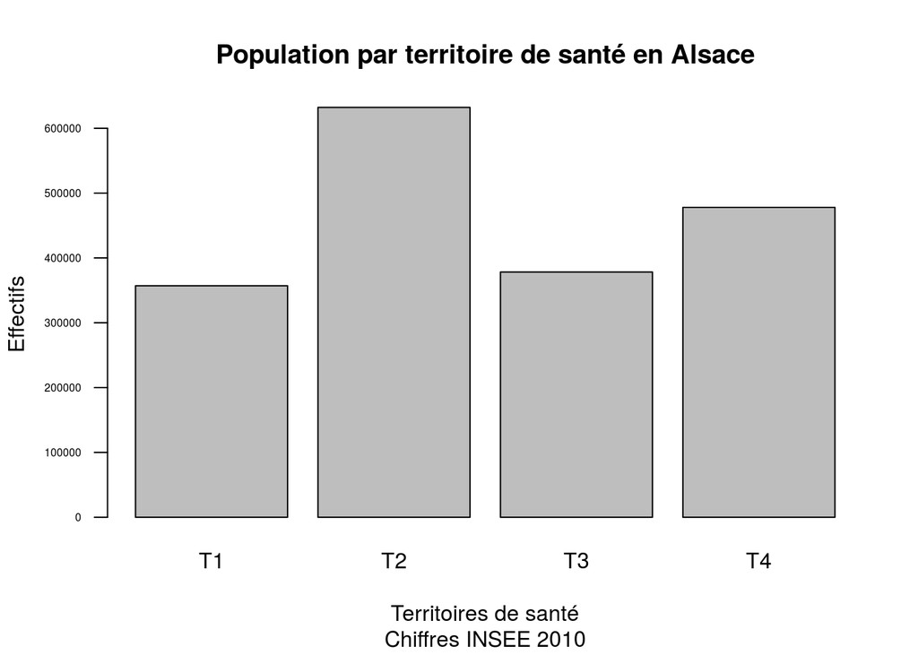

```r
barplot(pop.ts, names.arg = c("T1","T2","T3","T4"), main="Population par territoire de santé en Alsace", ylab = "Effectifs", xlab = "Territoires de santé", sub="Chiffres INSEE 2010", las=1, cex.axis=0.5)
```

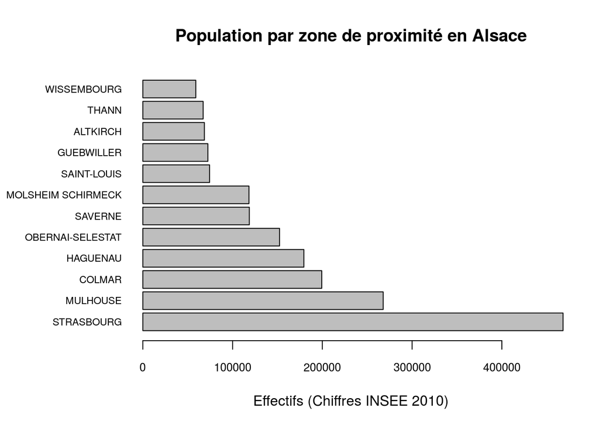

```r
par(mar=c(5.1,8.1,4.1,2.1))
barplot(sort(pop.zp, decreasing=TRUE), main="Population par zone de proximité en Alsace", ylab = "", xlab = "Effectifs (Chiffres INSEE 2010)", sub="", las=1, cex.axis=0.8, cex.names = 0.7, horiz = TRUE)
```

```r
par(mar=c(5.1,4.1,4.1,2.1))
```

## entrées par Territoire de santé

On creé une colonne supplémentaire *secteur* qui indique à quel secteur sanitaire correspond le RPU:

#### Nombre de RPU par territoire de santé

```r
rpu.ts <- tapply(d1$ENTREE,d1$secteur,length)
rpu.ts
```

```
##      1      2      3      4
##  59484  62981 109395 112213
```

#### taux de recours par territoire de santé

```r
rpu.ts/pop.ts
```

```
##    1    2    3    4
## 0.17 0.10 0.29 0.23
```

#### Taux standardisé pour 10.000 habitants

```r
rpu.ts * 10000 / pop.ts
```

```
##    1    2    3    4
## 1666  996 2891 2348
```

Remarques:

- en 2013: secteur 2, manque St Anne, pediatrie HTP, une partie des RPU HUS adultes. Secteur 4, manque CH Thann.
- en 2014: en cours d’année apparaissent St Anne, pédiatrie HUS (avril 2014), Diaconat Roosvelt (), Diaconat Strasbourg (). La clinique des 3 frontières devient propriété du CH de Mulhouse et change de Finess (Mai 2014). CH Thann en attente absobtion par Mulhouse (2015) ne fornit pas de RPU.

## Age moyen

```
 1  2  3  4
44 48 36 38
```

```
 1  2  3  4
27 25 27 27
```

```
 1  2  3  4
43 47 32 35
```

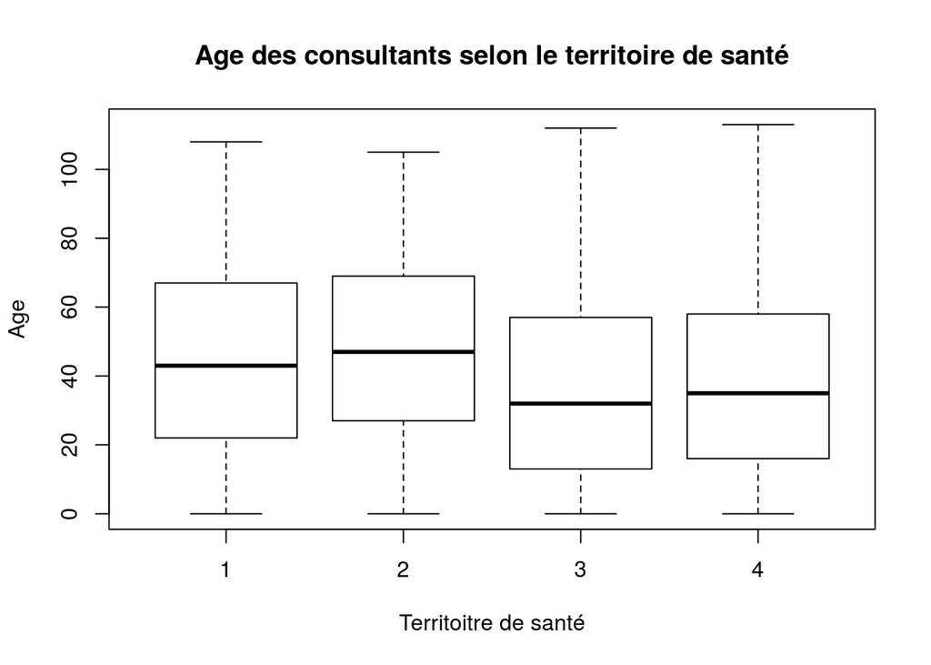

```
Call:
   aov(formula = age ~ territoire)

Terms:
                territoire Residuals
Sum of Squares     7009240 241978093
Deg. of Freedom          3    344059

Residual standard error: 27
Estimated effects may be unbalanced
10 observations deleted due to missingness
```

```
                Df    Sum Sq Mean Sq F value Pr(>F)
territoire       3   7009240 2336413    3322 <2e-16 ***
Residuals   344059 241978093     703
---
Signif. codes:  0 '***' 0.001 '**' 0.01 '*' 0.05 '.' 0.1 ' ' 1
10 observations deleted due to missingness
```

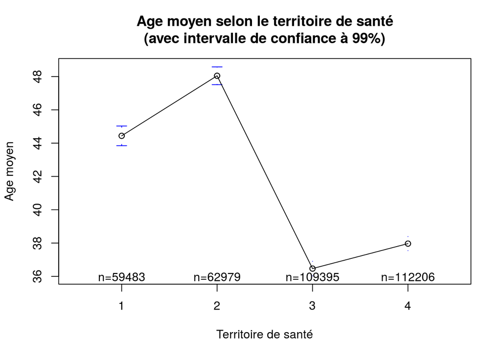

```
  Tukey multiple comparisons of means
    95% family-wise confidence level

Fit: aov(formula = age ~ territoire)

$territoire
     diff   lwr   upr p adj
2-1   3.6   3.2   4.0     0
3-1  -8.0  -8.3  -7.6     0
4-1  -6.5  -6.8  -6.1     0
3-2 -11.6 -11.9 -11.2     0
4-2 -10.1 -10.4  -9.7     0
4-3   1.5   1.2   1.8     0
```

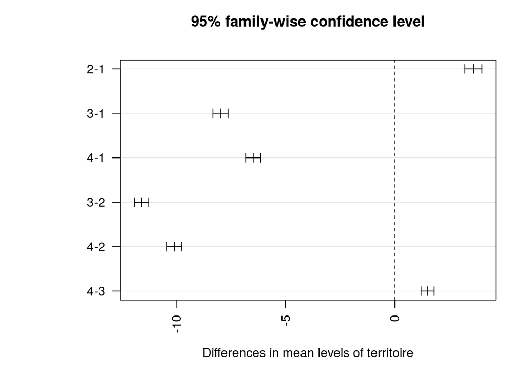

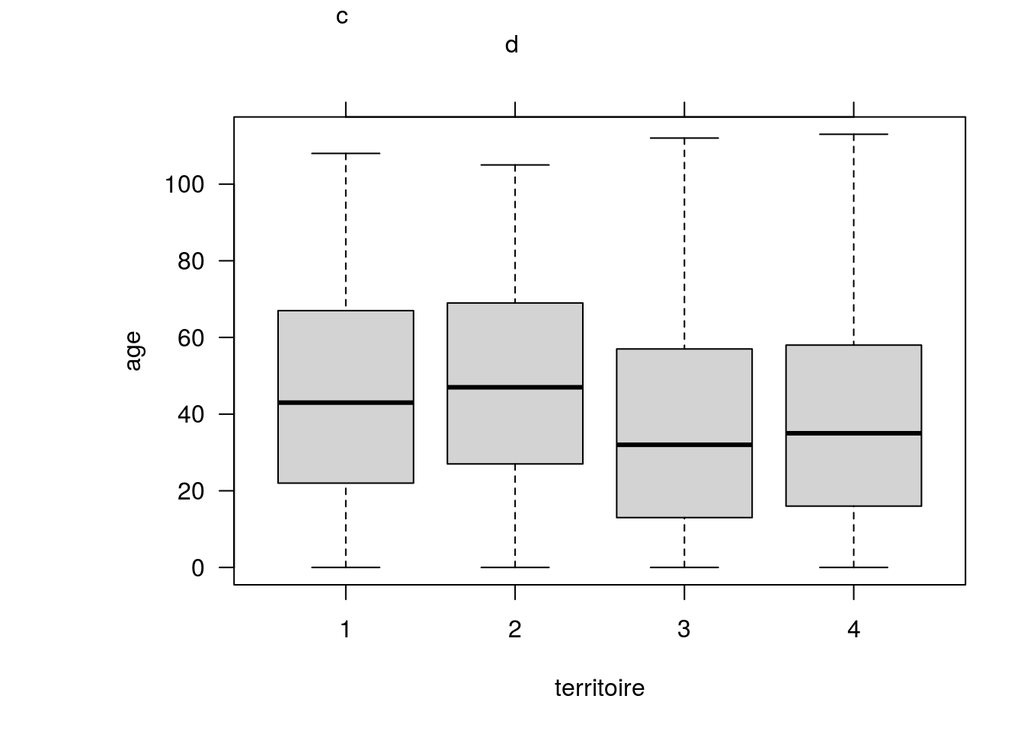

## Age moyen des adultes

Une critique de l’analyse précédente est que l’absence de la pédiatrie strasbourgeoise explique la moyenne d’age plus élevée dans le secteur 2. On refait la même analyse uniquement avec les 18 ans et plus:

[output not shown]

[output not shown]

[output not shown]

[figure not shown]

```
Call:
   aov(formula = age ~ territoire)

Terms:
                territoire Residuals
Sum of Squares      608272 124526395
Deg. of Freedom          3    260614

Residual standard error: 22
Estimated effects may be unbalanced
10 observations deleted due to missingness
```

```
                Df    Sum Sq Mean Sq F value Pr(>F)
territoire       3    608272  202757     424 <2e-16 ***
Residuals   260614 124526395     478
---
Signif. codes:  0 '***' 0.001 '**' 0.01 '*' 0.05 '.' 0.1 ' ' 1
10 observations deleted due to missingness
```

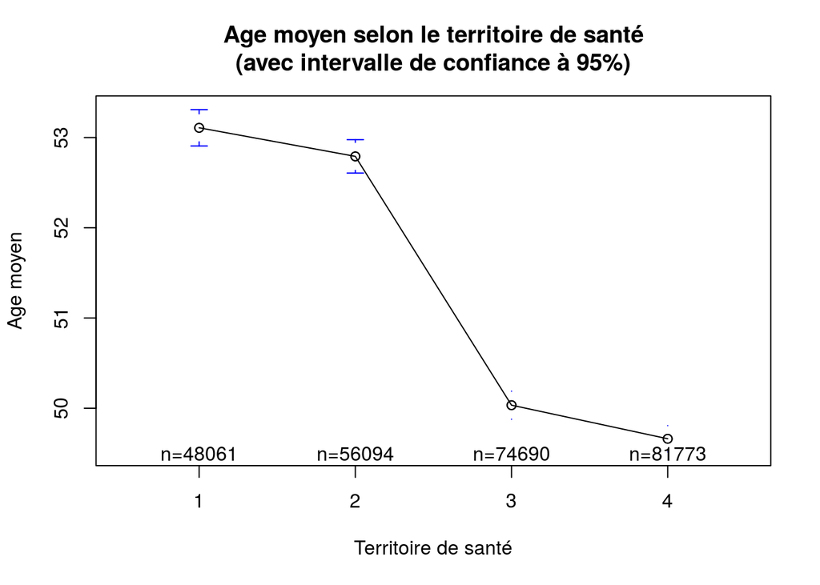

```
  Tukey multiple comparisons of means
    95% family-wise confidence level

Fit: aov(formula = age ~ territoire)

$territoire
     diff   lwr    upr p adj
2-1 -0.32 -0.67  0.032  0.09
3-1 -3.07 -3.40 -2.746  0.00
4-1 -3.45 -3.77 -3.124  0.00
3-2 -2.76 -3.07 -2.444  0.00
4-2 -3.13 -3.44 -2.822  0.00
4-3 -0.37 -0.66 -0.088  0.00
```

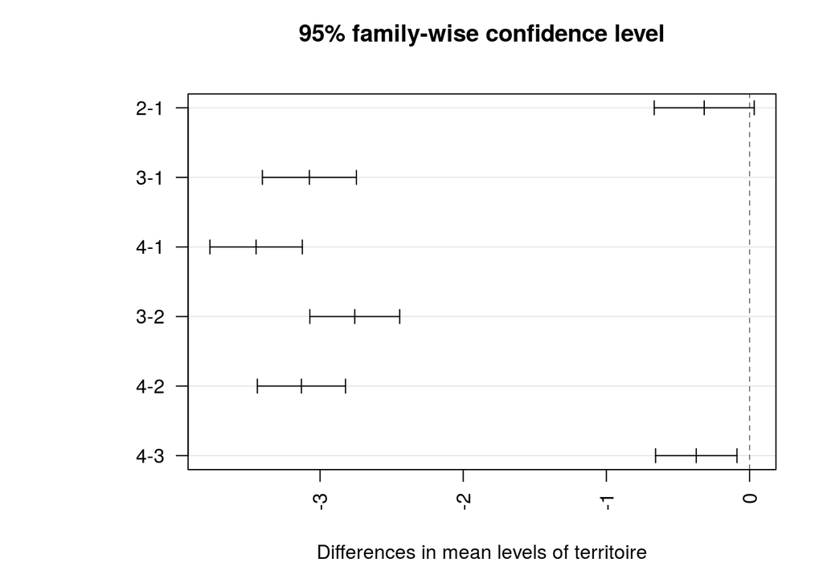

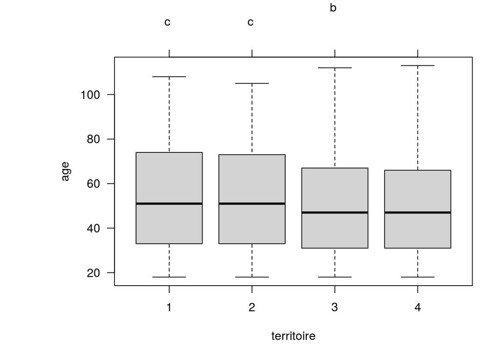